# Plotting glycans with glycanr package

## Prerequisits

As a help for plotting basic plots like boxplots of glycan data **glycanr** package can be used.

To install it we first need to install **devtools** package.

```r
# install additional packages to help us work with R
install.packages('devtools')
```

Now we can load **devtools** package.

```r
# load devtools package
library(devtools)
```

Devtools package has a function to help us install packages from GitHub. Using this function we will install **glycanr** package.

```r
# install 'glycanr' package from GitHub to help us plot glycans
install_github('iugrina/glycanr')
```

## Working with glycanr package

First we need to load the package.

```r
# load glycanr package
library(glycanr)
```

First we need to create a *data.frame* to simulate our glycan data.

```r
set.seed(123)
n <- 200
X <- data.frame(ID=1:n, GP1=runif(n), GP2=rexp(n, 0.3),
                GP3=rgamma(n, 2), cc=factor(sample(1:2, n, replace=TRUE)))
```

Now we have data.frame *X* where *GP* represents glycans, *ID* represents e.g. sample IDs and *cc* represents Case/Control status.

```r
head(X)
```

```
##   ID       GP1       GP2       GP3 cc
## 1  1 0.2875775 6.0104311 2.4551743  2
## 2  2 0.7883051 0.1001982 0.2778425  2
## 3  3 0.4089769 4.3448018 1.1637760  2
## 4  4 0.8830174 0.6659741 1.7217277  1
## 5  5 0.9404673 5.8381875 1.5926956  1
## 6  6 0.0455565 5.8788944 2.0702267  1
```

This data can now be plotted with *glyco.plot* function.

Basic usage is given as follows.

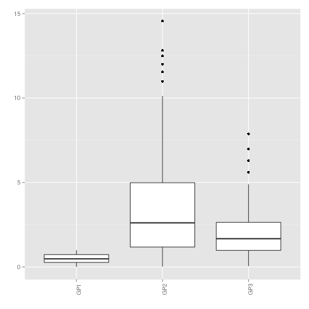

```r
glyco.plot(X)
```

It plots boxplots for every column whose name starts with 'GP'. To change boxplots with *violin plots* (represents the density of a data) option *violin* should be used.

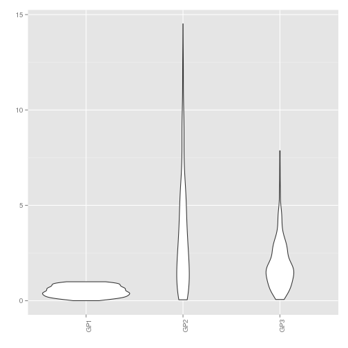

```r
glyco.plot(X, violin=TRUE)
```

To separate boxplots (or violin plots) into different layers option *collapse* should be used.

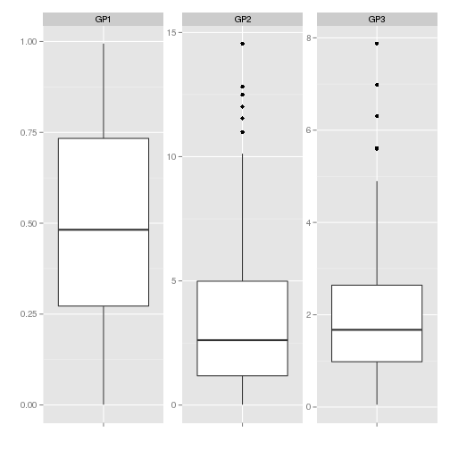

```r
glyco.plot(X, collapse=FALSE)
```

To plot log transformed data option *log.transform* should be used

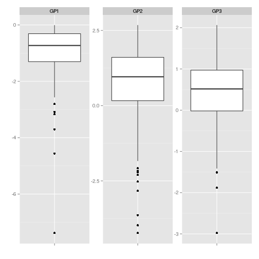

```r
glyco.plot(X, collapse=FALSE, log.transform=TRUE)
```

### Grouping

If you want to see the difference between groups with boxplots (or violin plots) option *group* should be used. It takes a character string representing the name of the column on grouping should be done.

Grouping by *cc* variable can be done like this.

```
## $p.val.unadj
##       GP1       GP2       GP3
## 0.6446870 0.4387528 0.4956589
##
## $p.val
## GP1 GP2 GP3
##   1   1   1
##
## $plot
```

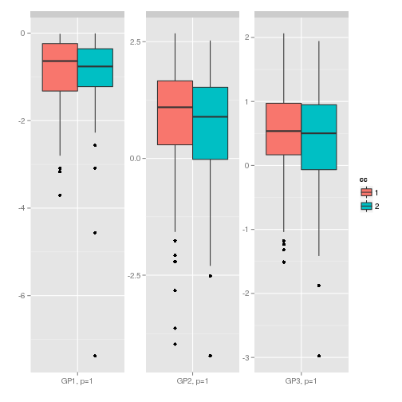

```r
glyco.plot(X, collapse=FALSE, log.transform=TRUE, group="cc")
```

As it can be seen the default option is to also conduct a test in difference between groups (Mann-Whitney-Wilcoxon for 2 groups, Kruskal-Wallis for more groups) and print the obtained p-values. The printed values are corrected for multiple testing before printing. As the output you get original p-values and adjusted p-values together with the plot.

Method for multiple testing correction can be adjusted by parameter *p.adjust.method*.

```
## $p.val.unadj
##       GP1       GP2       GP3
## 0.6446870 0.4387528 0.4956589
##
## $p.val
##      GP1      GP2      GP3
## 0.644687 0.644687 0.644687
##
## $plot
```

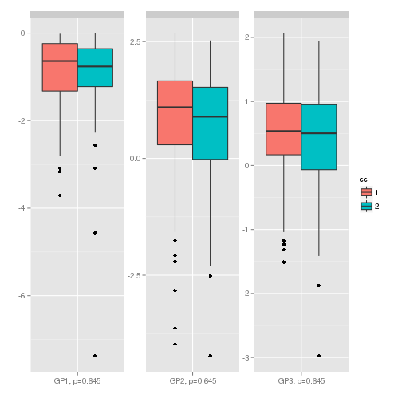

```r
glyco.plot(X, collapse=FALSE, log.transform=TRUE, group="cc", p.adjust.method="fdr")
```

Printing p-values in plots can be omitted with *print.p.values* parameter.

```
## $p.val.unadj
##       GP1       GP2       GP3
## 0.6446870 0.4387528 0.4956589
##
## $p.val
##      GP1      GP2      GP3
## 0.644687 0.644687 0.644687
##
## $plot
```

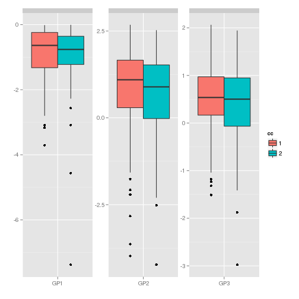

```r
glyco.plot(X, collapse=FALSE, log.transform=TRUE, group="cc", p.adjust.method="fdr",
           print.p.values=FALSE)
```

When grouping, by default, all glycans are plotted. To plot only those that differ statistically significant parameter *all* should be used.

## Choosing other columns

Function *glyco.plot* plots all columns whose name starts with **GP**. Since these plotting techniques can be used on other data as well there is the parameter *glyco.names* to choose which columns you want to use.

```
## $p.val.unadj
##       GP1       GP2
## 0.6446870 0.4387528
##
## $p.val
##      GP1      GP2
## 0.644687 0.644687
##
## $plot
```

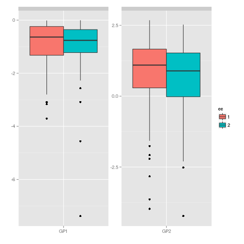

```r
glyco.plot(X, collapse=FALSE, log.transform=TRUE, group="cc", p.adjust.method="fdr",
           print.p.values=FALSE, glyco.names=c("GP1", "GP2"))
```